# General analysis of PTE multi-substrate data

#### 3.5.1.1 Slope extraction

I can try to look at the slopes of the normalized points, and compare them to their relative epistasis values. I can plot EE of POE on the x-axis, EE of POM on the y-axis, and color gradient the slope with positive values indicating that the “non-native” substrate has a better activity than native.

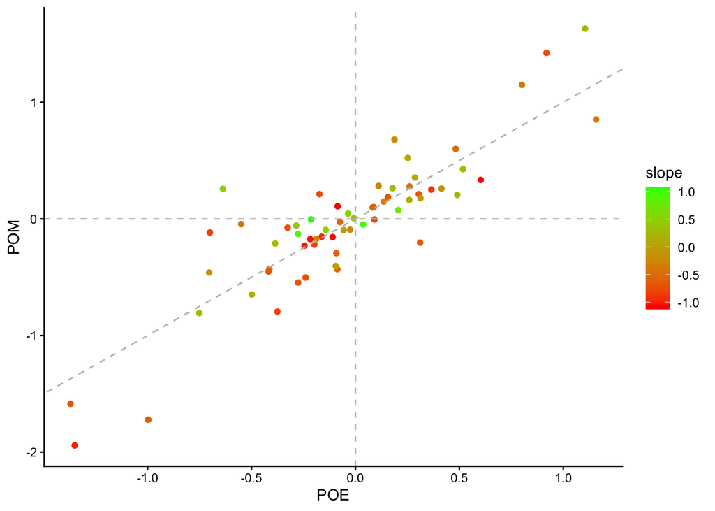

```r
poe_pom_corr <- poe_pom_norm_data %>%
  group_by(p233, p254, p271, p272, p306, p313, substrate, reference) %>%
  summarize(log.activity = mean(log.activity)) %>%
  ungroup() %>%
  mutate(across(1:6, ~ case_when(. == 0 ~ '0', . == 1 ~ 'x'))) %>%
  unite("geno", p233:p313, sep = "") %>%
  pivot_wider(names_from = substrate, values_from = log.activity) %>%
  mutate(slope = `1` - `0`) %>%
  select(geno, reference, slope) %>%
  merge(., test_ees %>% filter(sub %in% c("POE", "POM")) %>% select(geno, sub, new_val) %>% pivot_wider(names_from = sub, values_from = new_val), by = c("geno") ) %>%
  ggplot(aes(x = POE, y = POM, color = slope, label = geno)) +
  geom_point() +
  geom_abline(intercept = 0, slope = 1, lty = 2, col = "grey") +
  geom_vline(xintercept = 0, lty = 2, col = "grey") +
  geom_hline(yintercept = 0, lty = 2, col = "grey") +
  scale_colour_gradient(
    low = "red",
    high = "green",
  ) +
  theme_classic()

poe_pom_corr
```

```r
##ggsave("poe_pom_corr_fig.svg", plot = poe_pom_corr, width = 180/2, height = 247/3, dpi = 300, units = "mm")
```

We can also visualize it with labels for easier inspection of genotypes:

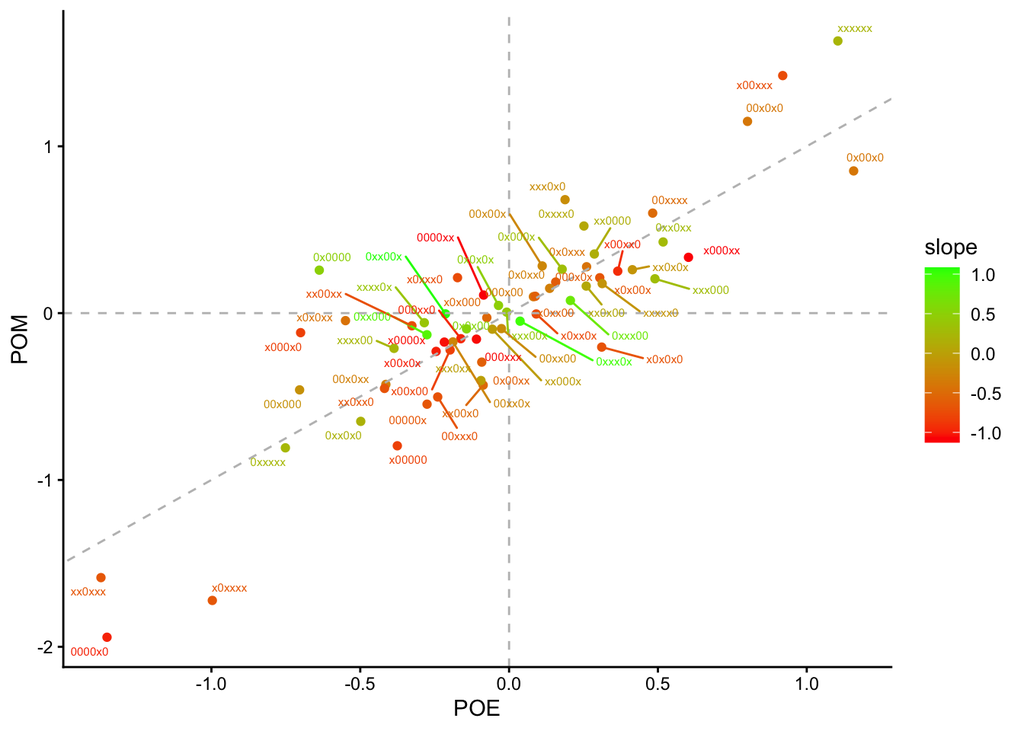

```r
poe_pom_corr_lab <- poe_pom_corr + geom_text_repel(size = 2, max.overlaps = Inf)

poe_pom_corr_lab
```

```r
##ggsave("poe_pom_corr_lab_fig.svg", plot = poe_pom_corr_lab, width = 180/2, height = 247/3, dpi = 300, units = "mm")
```

### 3.5.2 Paraoxon-ethyl (POE) vs Parathion-ethyl (PTE)

```r
poe_pte_data <- processed_data %>%
  filter(substrate %in% c("POE", "PTE")) %>%
  mutate(substrate = case_when(substrate == "POE" ~ 0, substrate == "PTE" ~ 1)) %>%
  select(-c(replicate, exp_day, plate_id))

poe_pte_wt_mean <- mean(poe_pte_data %>% filter(if_all(1:7, ~. == 0)) %>% pull(activity))

poe_pte_norm_data <- poe_pte_data %>%
  mutate(activity = activity/poe_pte_wt_mean,
         log.activity = log10(activity))
```

After constructing the data, we can visualize the distribution based on different substrate:

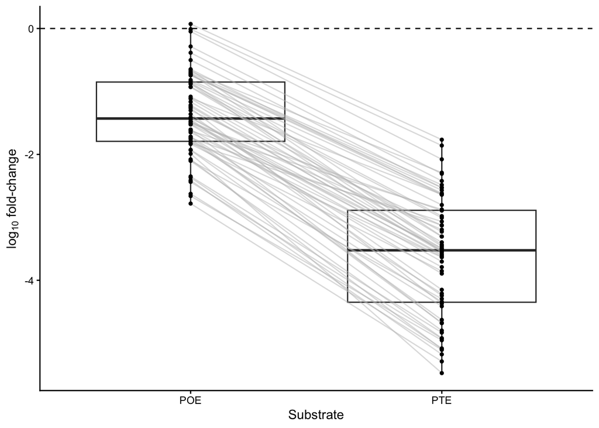

```r
poe_pte_box_fig <- poe_pte_norm_data %>%
  group_by(p233, p254, p271, p272, p306, p313, substrate, reference) %>%
  summarize(log.activity = mean(log.activity)) %>%
  ungroup() %>%
  mutate(substrate = case_when(substrate == 0 ~ "POE", substrate == 1 ~ "PTE")) %>%
  ggplot(aes(x = substrate, y = log.activity)) +
  geom_boxplot() +
  geom_line(aes(group=reference), color = "grey", alpha = 0.5) + # clever way to connect points between group
  geom_point(size = 1) +
  geom_hline(yintercept = 0, lty = 2) +
  labs(x = "Substrate", y = expression("log"[10]*" fold-change")) +
  theme_classic()

poe_pte_box_fig
```

```r
##ggsave("poe_pte_box_fig.svg", plot = poe_pte_box_fig, width = 180/2, height = 247/3, dpi = 300, units = "mm")
```

These are definitely skewed as expected, less interesting information than with paraoxon-methyl.

#### 3.5.2.1 Slope extraction

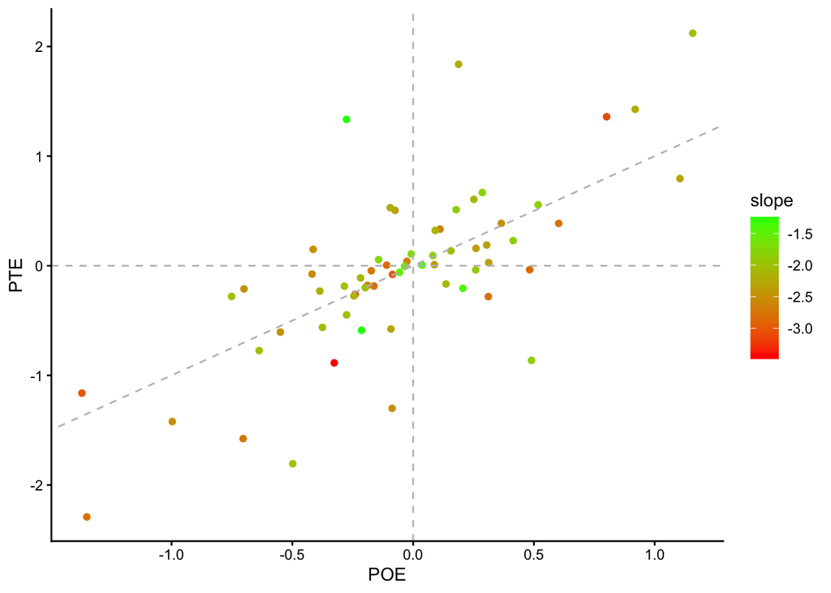

```r
poe_pte_corr <- poe_pte_norm_data %>%
  group_by(p233, p254, p271, p272, p306, p313, substrate, reference) %>%
  summarize(log.activity = mean(log.activity)) %>%
  ungroup() %>%
  mutate(across(1:6, ~ case_when(. == 0 ~ '0', . == 1 ~ 'x'))) %>%
  unite("geno", p233:p313, sep = "") %>%
  pivot_wider(names_from = substrate, values_from = log.activity) %>%
  mutate(slope = `1` - `0`) %>%
  select(geno, reference, slope) %>%
  merge(., test_ees %>% filter(sub %in% c("POE", "PTE")) %>% select(geno, sub, new_val) %>% pivot_wider(names_from = sub, values_from = new_val), by = c("geno") ) %>%
  ggplot(aes(x = POE, y = PTE, color = slope, label = geno)) +
  geom_point() +
  geom_abline(intercept = 0, slope = 1, lty = 2, col = "grey") +
  geom_vline(xintercept = 0, lty = 2, col = "grey") +
  geom_hline(yintercept = 0, lty = 2, col = "grey") +
  scale_colour_gradient(
    low = "red",
    high = "green",
  ) +
  theme_classic()

poe_pte_corr
```

```r
##ggsave("poe_pte_corr_fig.svg", plot = poe_pte_corr, width = 180/2, height = 247/3, dpi = 300, units = "mm")
```

We can also visualize it with labels for easier inspection of genotypes:

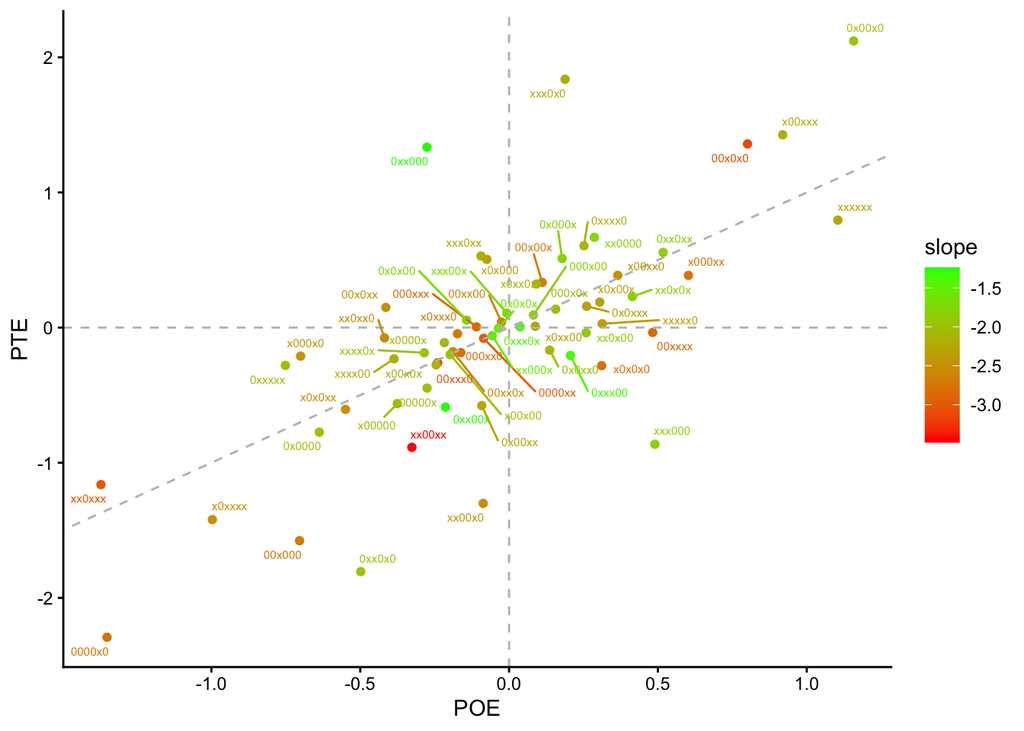

```r
poe_pte_corr_lab <- poe_pte_corr + geom_text_repel(size = 2, max.overlaps = Inf)

poe_pte_corr_lab
```

```r
##ggsave("poe_pte_corr_lab_fig.svg", plot = poe_pte_corr_lab, width = 180/2, height = 247/3, dpi = 300, units = "mm")
```

### 3.5.3 2-napthylhexanoate (2NH) vs Butyrate (butyrate)

```r
nh_but_data <- processed_data %>%
  filter(substrate %in% c("2NH", "butyrate")) %>%
  mutate(substrate = case_when(substrate == "2NH" ~ 0, substrate == "butyrate" ~ 1)) %>%
  select(-c(replicate, exp_day, plate_id))

nh_but_wt_mean <- mean(nh_but_data %>% filter(if_all(1:7, ~. == 0)) %>% pull(activity))

nh_but_norm_data <- nh_but_data %>%
  mutate(activity = activity/nh_but_wt_mean,
         log.activity = log10(activity))
```

After constructing the data, we can visualize the distribution based on different substrate:

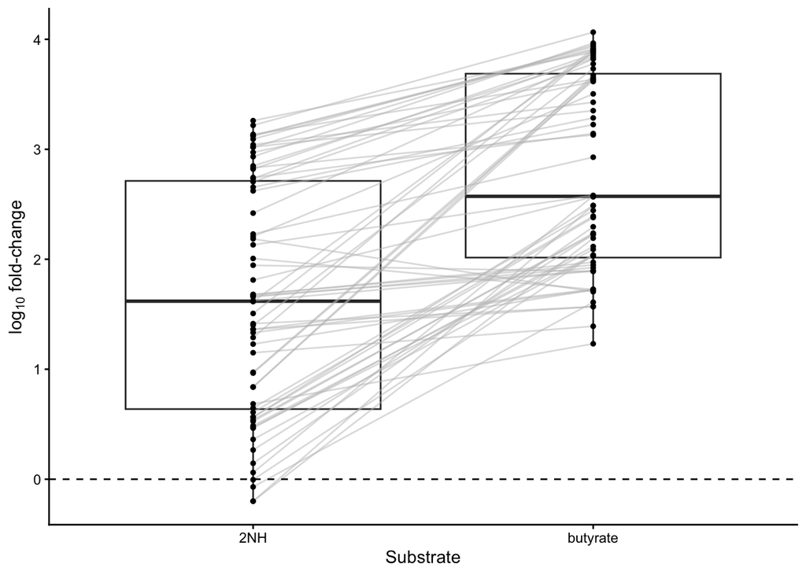

```r
nh_but_box_fig <- nh_but_norm_data %>%
  group_by(p233, p254, p271, p272, p306, p313, substrate, reference) %>%
  summarize(log.activity = mean(log.activity)) %>%
  ungroup() %>%
  mutate(substrate = case_when(substrate == 0 ~ "2NH", substrate == 1 ~ "butyrate")) %>%
  ggplot(aes(x = substrate, y = log.activity)) +
  geom_boxplot() +
  geom_line(aes(group=reference), color = "grey", alpha = 0.5) + # clever way to connect points between group
  geom_point(size = 1) +
  geom_hline(yintercept = 0, lty = 2) +
  labs(x = "Substrate", y = expression("log"[10]*" fold-change")) +
  theme_classic()

nh_but_box_fig
```

```r
##ggsave("nh_but_box_fig.svg", plot = nh_but_box_fig, width = 180/2, height = 247/3, dpi = 300, units = "mm")
```

I forgot that lysate activity for butyrate is better than 2NH, this will make for an interesting investigation into epistasis.

#### 3.5.3.1 Slope extraction

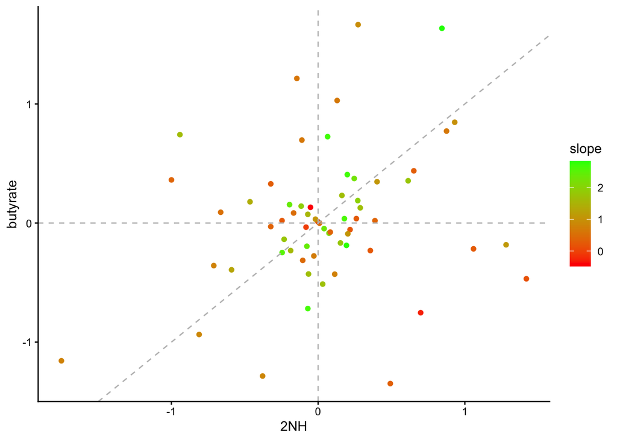

```r
nh_but_corr <- nh_but_norm_data %>%
  group_by(p233, p254, p271, p272, p306, p313, substrate, reference) %>%
  summarize(log.activity = mean(log.activity)) %>%
  ungroup() %>%
  mutate(across(1:6, ~ case_when(. == 0 ~ '0', . == 1 ~ 'x'))) %>%
  unite("geno", p233:p313, sep = "") %>%
  pivot_wider(names_from = substrate, values_from = log.activity) %>%
  mutate(slope = `1` - `0`) %>%
  select(geno, reference, slope) %>%
  merge(., test_ees %>% filter(sub %in% c("2NH", "butyrate")) %>% select(geno, sub, new_val) %>% pivot_wider(names_from = sub, values_from = new_val), by = c("geno") ) %>%
  ggplot(aes(x = `2NH`, y = butyrate, color = slope, label = geno)) +
  geom_point() +
  geom_abline(intercept = 0, slope = 1, lty = 2, col = "grey") +
  geom_vline(xintercept = 0, lty = 2, col = "grey") +
  geom_hline(yintercept = 0, lty = 2, col = "grey") +
  scale_colour_gradient(
    low = "red",
    high = "green",
  ) +
  theme_classic()

nh_but_corr
```

```r
##ggsave("nh_but_corr_corr_fig.svg", plot = nh_but_corr, width = 180/2, height = 247/3, dpi = 300, units = "mm")
```

We can also visualize it with labels for easier inspection of genotypes:

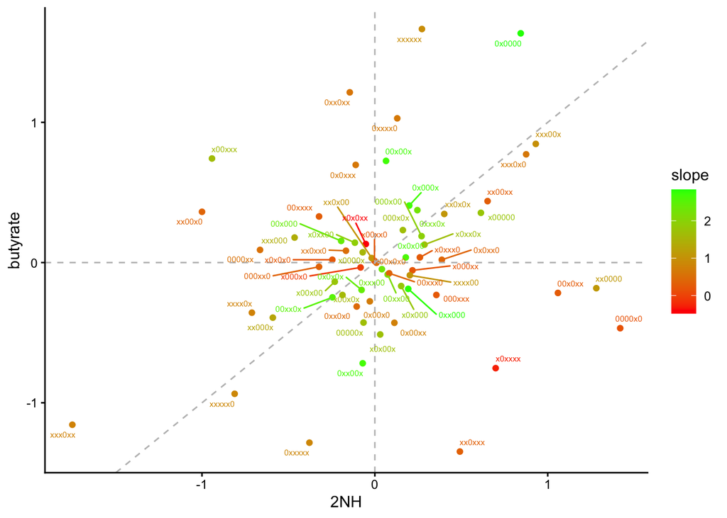

```r
nh_but_corr_lab <- nh_but_corr + geom_text_repel(size = 2, max.overlaps = Inf)

nh_but_corr_lab
```

```r
##ggsave("nh_but_corr_lab_fig.svg", plot = nh_but_corr_lab, width = 180/2, height = 247/3, dpi = 300, units = "mm")
```

### 3.5.4 Paraoxon-ethyl (POE) vs 2-napthylhexanoate (2NH)

```r
poe_nh_data <- processed_data %>%
  filter(substrate %in% c("POE", "2NH")) %>%
  mutate(substrate = case_when(substrate == "POE" ~ 0, substrate == "2NH" ~ 1)) %>%
  select(-c(replicate, exp_day, plate_id))

poe_nh_wt_mean <- mean(poe_nh_data %>% filter(if_all(1:7, ~. == 0)) %>% pull(activity))

poe_nh_norm_data <- poe_nh_data %>%
  mutate(activity = activity/poe_nh_wt_mean,
         log.activity = log10(activity))
```

After constructing the data, we can visualize the distribution based on different substrate:

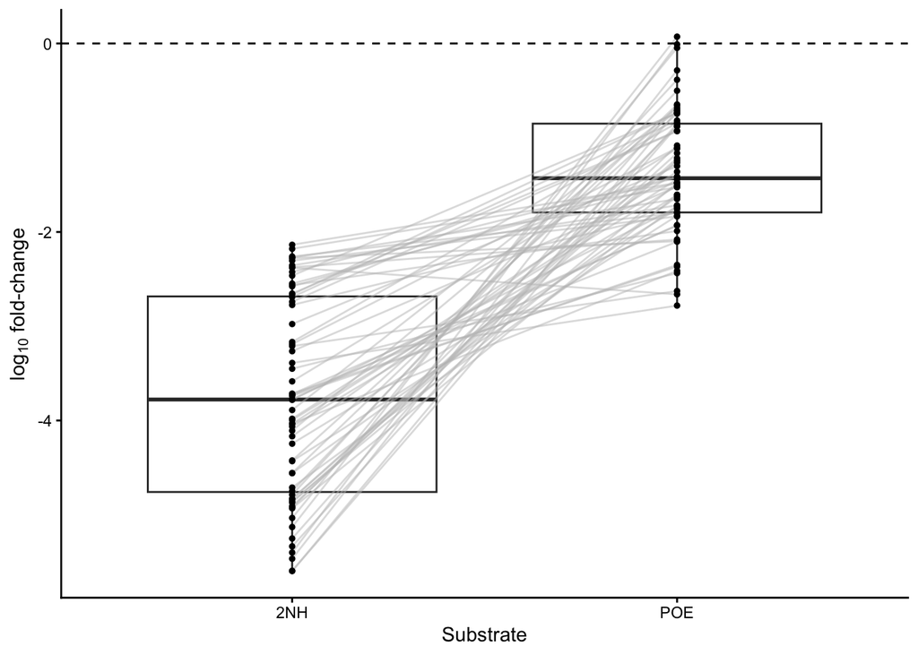

```r
poe_2nh_box_fig <- poe_nh_norm_data %>%
  group_by(p233, p254, p271, p272, p306, p313, substrate, reference) %>%
  summarize(log.activity = mean(log.activity)) %>%
  ungroup() %>%
  mutate(substrate = case_when(substrate == 0 ~ "POE", substrate == 1 ~ "2NH")) %>%
  ggplot(aes(x = substrate, y = log.activity)) +
  geom_boxplot() +
  geom_line(aes(group=reference), color = "grey", alpha = 0.5) + # clever way to connect points between group
  geom_point(size = 1) +
  geom_hline(yintercept = 0, lty = 2) +
  labs(x = "Substrate", y = expression("log"[10]*" fold-change")) +
  theme_classic()

poe_2nh_box_fig
```

```r
##ggsave("poe_2nh_box_fig.svg", plot = poe_2nh_box_fig, width = 180/2, height = 247/3, dpi = 300, units = "mm")
```

Still interesting here to examine the ratios, and consider the epistasis at those genotypes.

#### 3.5.4.1 Slope extraction

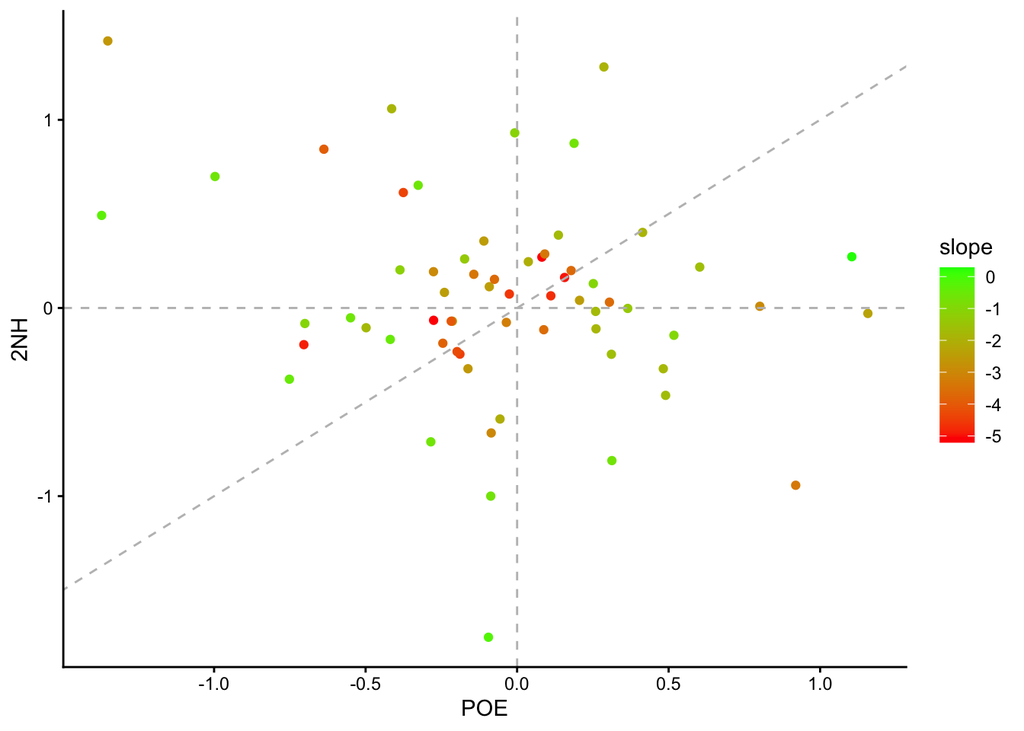

```r
poe_2nh_corr <- poe_nh_norm_data %>%
  group_by(p233, p254, p271, p272, p306, p313, substrate, reference) %>%
  summarize(log.activity = mean(log.activity)) %>%
  ungroup() %>%
  mutate(across(1:6, ~ case_when(. == 0 ~ '0', . == 1 ~ 'x'))) %>%
  unite("geno", p233:p313, sep = "") %>%
  pivot_wider(names_from = substrate, values_from = log.activity) %>%
  mutate(slope = `1` - `0`) %>%
  select(geno, reference, slope) %>%
  merge(., test_ees %>% filter(sub %in% c("POE", "2NH")) %>% select(geno, sub, new_val) %>% pivot_wider(names_from = sub, values_from = new_val), by = c("geno") ) %>%
  ggplot(aes(x = POE, y = `2NH`, color = slope, label = geno)) +
  geom_point() +
  geom_abline(intercept = 0, slope = 1, lty = 2, col = "grey") +
  geom_vline(xintercept = 0, lty = 2, col = "grey") +
  geom_hline(yintercept = 0, lty = 2, col = "grey") +
  scale_colour_gradient(
    low = "red",
    high = "green",
  ) +
  theme_classic()

poe_2nh_corr
```

```r
##ggsave("poe_2nh_corr_corr_fig.svg", plot = poe_2nh_corr, width = 180/2, height = 247/3, dpi = 300, units = "mm")
```

We can also visualize it with labels for easier inspection of genotypes:

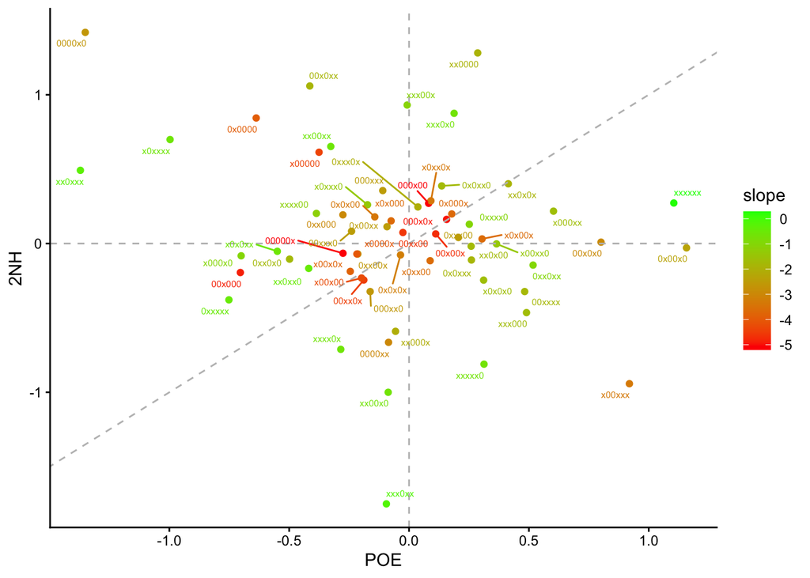

```r
poe_2nh_corr_lab <- poe_2nh_corr + geom_text_repel(size = 2, max.overlaps = Inf)

poe_2nh_corr_lab
```

```r
##ggsave("poe_2nh_corr_lab_fig.svg", plot = poe_2nh_corr_lab, width = 180/2, height = 247/3, dpi = 300, units = "mm")
```

### 3.5.5 Paraoxon-ethyl (POE) vs Parathion-methyl (PTM)

```r
poe_ptm_data <- processed_data %>%
  filter(substrate %in% c("POE", "PTM")) %>%
  mutate(substrate = case_when(substrate == "POE" ~ 0, substrate == "PTM" ~ 1)) %>%
  select(-c(replicate, exp_day, plate_id))

poe_ptm_wt_mean <- mean(poe_ptm_data %>% filter(if_all(1:7, ~. == 0)) %>% pull(activity))

poe_ptm_norm_data <- poe_ptm_data %>%
  mutate(activity = activity/poe_ptm_wt_mean,
         log.activity = log10(activity))
```

After constructing the data, we can visualize the distribution based on different substrate:

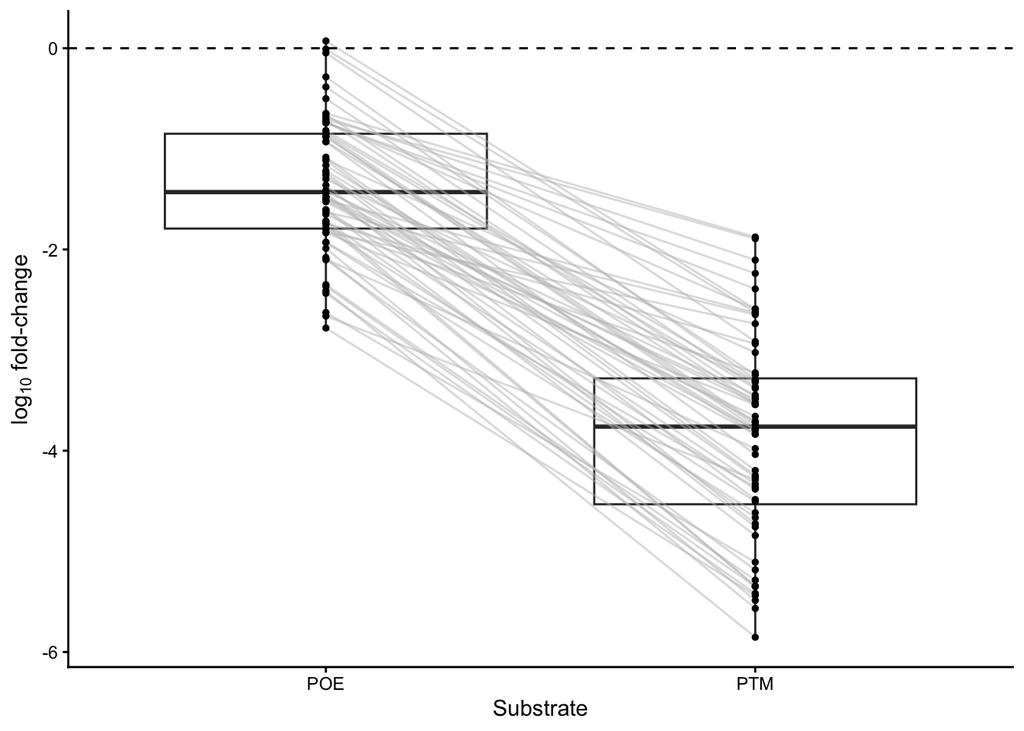

```r
poe_ptm_norm_data %>%
  group_by(p233, p254, p271, p272, p306, p313, substrate, reference) %>%
  summarize(log.activity = mean(log.activity)) %>%
  ungroup() %>%
  mutate(substrate = case_when(substrate == 0 ~ "POE", substrate == 1 ~ "PTM")) %>%
  ggplot(aes(x = substrate, y = log.activity)) +
  geom_boxplot() +
  geom_line(aes(group=reference), color = "grey", alpha = 0.5) + # clever way to connect points between group
  geom_point(size = 1) +
  geom_hline(yintercept = 0, lty = 2) +
  labs(x = "Substrate", y = expression("log"[10]*" fold-change")) +
  theme_classic()
```

These are definitely skewed as expected, less interesting information than with paraoxon-methyl.

#### 3.5.5.1 Slope extraction

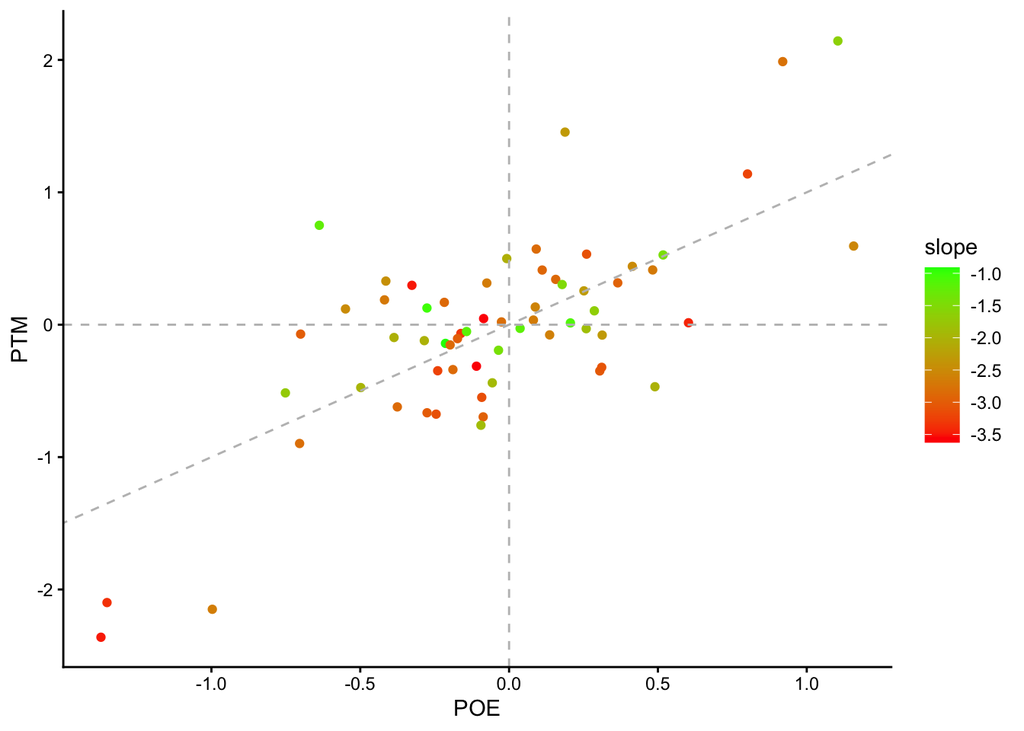

```r
poe_ptm_corr <- poe_ptm_norm_data %>%
  group_by(p233, p254, p271, p272, p306, p313, substrate, reference) %>%
  summarize(log.activity = mean(log.activity)) %>%
  ungroup() %>%
  mutate(across(1:6, ~ case_when(. == 0 ~ '0', . == 1 ~ 'x'))) %>%
  unite("geno", p233:p313, sep = "") %>%
  pivot_wider(names_from = substrate, values_from = log.activity) %>%
  mutate(slope = `1` - `0`) %>%
  select(geno, reference, slope) %>%
  merge(., test_ees %>% filter(sub %in% c("POE", "PTM")) %>% select(geno, sub, new_val) %>% pivot_wider(names_from = sub, values_from = new_val), by = c("geno") ) %>%
  ggplot(aes(x = POE, y = PTM, color = slope, label = geno)) +
  geom_point() +
  geom_abline(intercept = 0, slope = 1, lty = 2, col = "grey") +
  geom_vline(xintercept = 0, lty = 2, col = "grey") +
  geom_hline(yintercept = 0, lty = 2, col = "grey") +
  scale_colour_gradient(
    low = "red",
    high = "green",
  ) +
  theme_classic()

poe_ptm_corr
```

## 3.6 All-by-all comparison with normalization with wtPTE-POE

It may be better to visualize all plots compated to wtPTE-POE, then plot on 2D scatted plots with phenotype instead of epistasis. No need to color by slope values as these are inherently included in the data: deviation away from the 1-to-1 line means switching is unfavorable (below) or favorable (above) to substrate on y-axis

```r
all_by_all_data <- processed_data %>%
  select(-c(replicate, exp_day, plate_id))

all_wt_mean <- mean(all_by_all_data %>% filter(if_all(1:6, ~. == 0)) %>% filter(substrate == "POE") %>% pull(activity))

all_by_all_data_norm <- all_by_all_data %>%
  mutate(activity = activity/all_wt_mean,
         log.activity = log10(activity))

# Create a list of all combinations of substrates
substrate_combinations <- combn(unique(all_by_all_data_norm$substrate), 2, simplify = FALSE)

plots <- lapply(substrate_combinations, function(subs) {
  ggplot(all_by_all_data_norm %>%
           filter(substrate %in% subs) %>%
           group_by(p233, p254, p271, p272, p306, p313, substrate, reference) %>%
           summarize(log.activity = mean(log.activity)) %>%
           ungroup() %>%
           mutate(substrate = case_when(substrate == subs[1] ~ "sub1", substrate == subs[2] ~ "sub2")) %>%
           mutate(across(1:6, ~ case_when(. == 0 ~ '0', . == 1 ~ 'x'))) %>%
           unite("geno", p233:p313, sep = "") %>%
           mutate(mut_order = str_count(geno, "x")) %>%
           pivot_wider(names_from = substrate, values_from = log.activity),
         aes(x = sub1, y = sub2, color = mut_order)) +
    geom_point() +
    geom_abline(slope = 1, intercept = 0, lty = 2) +
    labs(x = paste("POE-normalized phenotype of ", subs[1], sep=""),
         y = paste("POE-normalized phenotype of ", subs[2], sep="")) +
    #geom_text_repel(size = 2, max.overlaps = Inf) +
    theme_classic() +
    theme(legend.position = "none", axis.title = element_text(size = 6))
})
```

I also exported the `all_by_all_data_norm` to create an HTML widget for better visualization of the genotypes

```r
write_csv(all_by_all_data_norm, "all_by_all.csv")
```

### 3.6.1 Correlations

I can calculate two main parameters: pearson correlation and spearman correlation for each substrate pair

```r
pearsons <- lapply(substrate_combinations, function(subs) {

all_by_all_data_norm %>%
    filter(substrate %in% subs) %>%
    group_by(p233, p254, p271, p272, p306, p313, substrate, reference) %>%
    summarize(log.activity = mean(log.activity)) %>%
    ungroup() %>%
    mutate(substrate = case_when(substrate == subs[1] ~ "sub1", substrate == subs[2] ~ "sub2")) %>%
    mutate(across(1:6, ~ case_when(. == 0 ~ '0', . == 1 ~ 'x'))) %>%
    unite("geno", p233:p313, sep = "") %>%
    mutate(mut_order = str_count(geno, "x")) %>%
    pivot_wider(names_from = substrate, values_from = log.activity) %>%
    summarise(correlation = cor.test(sub1, sub2, method = "pearson")$estimate) %>%
    pull(correlation)

})

spearmans <- lapply(substrate_combinations, function(subs) {

all_by_all_data_norm %>%
    filter(substrate %in% subs) %>%
    group_by(p233, p254, p271, p272, p306, p313, substrate, reference) %>%
    summarize(log.activity = mean(log.activity)) %>%
    ungroup() %>%
    mutate(substrate = case_when(substrate == subs[1] ~ "sub1", substrate == subs[2] ~ "sub2")) %>%
    mutate(across(1:6, ~ case_when(. == 0 ~ '0', . == 1 ~ 'x'))) %>%
    unite("geno", p233:p313, sep = "") %>%
    mutate(mut_order = str_count(geno, "x")) %>%
    pivot_wider(names_from = substrate, values_from = log.activity) %>%
    summarise(correlation = cor.test(sub1, sub2, method = "spearman")$estimate) %>%
    pull(correlation)

})

one_to_one <- lapply(substrate_combinations, function(subs) {

all_by_all_data_norm %>%
    filter(substrate %in% subs) %>%
    group_by(p233, p254, p271, p272, p306, p313, substrate, reference) %>%
    summarize(log.activity = mean(log.activity)) %>%
    ungroup() %>%
    mutate(substrate = case_when(substrate == subs[1] ~ "sub1", substrate == subs[2] ~ "sub2")) %>%
    mutate(across(1:6, ~ case_when(. == 0 ~ '0', . == 1 ~ 'x'))) %>%
    unite("geno", p233:p313, sep = "") %>%
    mutate(mut_order = str_count(geno, "x")) %>%
    pivot_wider(names_from = substrate, values_from = log.activity) %>%
    summarise(correlation = cor.test(sub1, sub2, method = "spearman")$estimate) %>%
    pull(correlation)

})

sub_stats <- tibble(sub1 = unlist(substrate_combinations)[seq(1, length(unlist(substrate_combinations)), by = 2)],
       sub2 = unlist(substrate_combinations)[seq(2, length(unlist(substrate_combinations)), by = 2)],
       pearsons = unlist(pearsons),
       spearman = unlist(spearmans))

knitr::kable(sub_stats)
```

| sub1 | sub2 | pearsons | spearman |
| --- | --- | --- | --- |
| 2NH | acetate | 0.6099522 | 0.5321429 |
| 2NH | butyrate | 0.6033486 | 0.5433150 |
| 2NH | DHC | -0.7820396 | -0.8168498 |
| 2NH | POE | -0.4635359 | -0.4797619 |
| 2NH | POM | -0.1889441 | -0.2302198 |
| 2NH | PTE | -0.3179020 | -0.3508700 |
| 2NH | PTM | -0.1500708 | -0.1747253 |
| 2NH | tbbl | 0.1710459 | 0.1701923 |
| acetate | butyrate | 0.9269353 | 0.9641026 |
| acetate | DHC | -0.5974478 | -0.5679945 |
| acetate | POE | 0.0734839 | 0.1831960 |
| acetate | POM | 0.4879497 | 0.5574634 |
| acetate | PTE | 0.3080770 | 0.3957418 |
| acetate | PTM | 0.5138817 | 0.5772894 |
| acetate | tbbl | 0.3280735 | 0.4391484 |
| butyrate | DHC | -0.6703670 | -0.6222527 |
| butyrate | POE | 0.0662456 | 0.1209249 |
| butyrate | POM | 0.5273499 | 0.5265110 |
| butyrate | PTE | 0.3344322 | 0.3460165 |
| butyrate | PTM | 0.5698519 | 0.5565934 |
| butyrate | tbbl | 0.4096695 | 0.3647436 |
| DHC | POE | 0.5178930 | 0.5321429 |
| DHC | POM | 0.0464575 | 0.0518315 |
| DHC | PTE | 0.2971959 | 0.3136905 |
| DHC | PTM | -0.0032397 | 0.0137821 |
| DHC | tbbl | 0.0122845 | -0.0628663 |
| POE | POM | 0.7895920 | 0.7625458 |
| POE | PTE | 0.8814803 | 0.8682692 |
| POE | PTM | 0.7054229 | 0.7038919 |
| POE | tbbl | 0.4329445 | 0.4506410 |
| POM | PTE | 0.9051426 | 0.8963828 |
| POM | PTM | 0.9597633 | 0.9571886 |
| POM | tbbl | 0.5013798 | 0.4890110 |
| PTE | PTM | 0.9025238 | 0.9093407 |
| PTE | tbbl | 0.5209229 | 0.5657051 |
| PTM | tbbl | 0.5171907 | 0.5186813 |

```r
#write_csv(sub_stats, "sub_stats.csv")
```

Plot a correlation heatmap

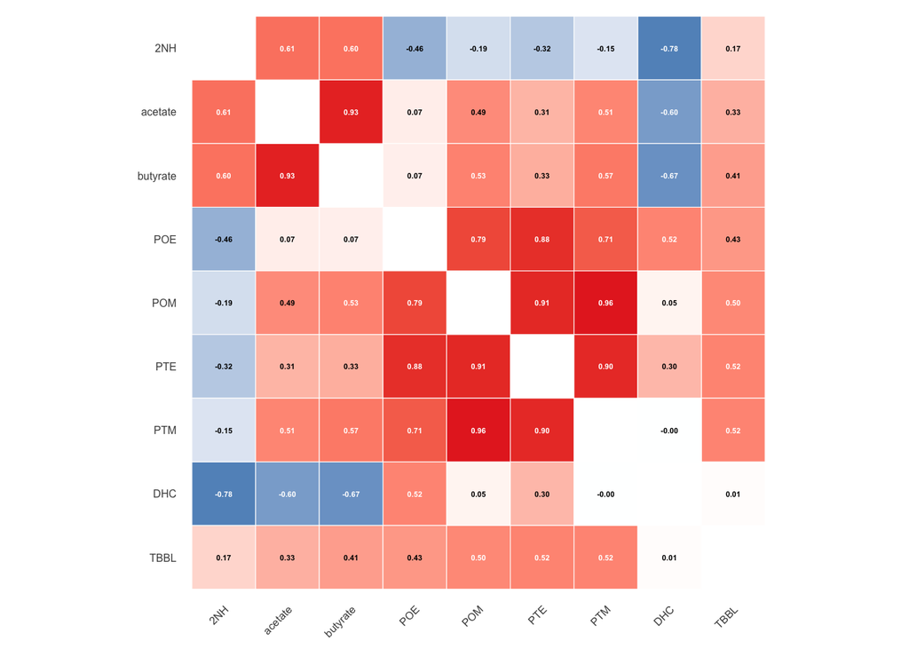

```r
# 1. Update the labels and the ordering vector first
sub_order <- c("2NH", "acetate", "butyrate", "POE", "POM", "PTE", "PTM", "DHC", "TBBL")

cor_plot_data <- bind_rows(sub_stats, (sub_stats %>% rename(sub1 = sub2, sub2 = sub1))) %>%
  # Update names to match the new order vector
  mutate(across(c(sub1, sub2), ~ ifelse(. == "tbbl", "TBBL", .))) %>%
  distinct() %>%
  filter(sub1 %in% sub_order & sub2 %in% sub_order) %>%
  mutate(
    sub1 = factor(sub1, levels = rev(sub_order)), # Reversed for Y-axis (Top to Bottom)
    sub2 = factor(sub2, levels = sub_order)       # Standard for X-axis (Left to Right)
  )

# 2. Plot
tile <- ggplot(cor_plot_data, aes(x = sub2, y = sub1, fill = pearsons)) +
  geom_tile(color = "white") +
  geom_text(aes(label = sprintf("%.2f", pearsons)),
            size = 1.5,
            color = ifelse(abs(cor_plot_data$pearsons) > 0.5, "white", "black"),
            fontface = "bold") +
  scale_fill_gradient2(
    low = "#1F78B4", mid = "white", high = "#E31A1C",
    midpoint = 0, limit = c(-1, 1)) +
  theme_minimal() +
  theme(
    axis.text.x = element_text(angle = 45, vjust = 1, hjust = 1),
    axis.text = element_text(size = 6),
    axis.title = element_blank(),
    panel.grid = element_blank(),
    legend.position = "none"
  ) +
  coord_fixed()

tile
```

```r
ggsave("fig_2_b.svg", plot = tile, width = 180/3, height = 247/3, dpi = 600, units = "mm")
```

What about correlations of SMEs and EEs across substrates positions

### 3.6.2 Correlations between them

Calculate the correlations for each between substrates across positions

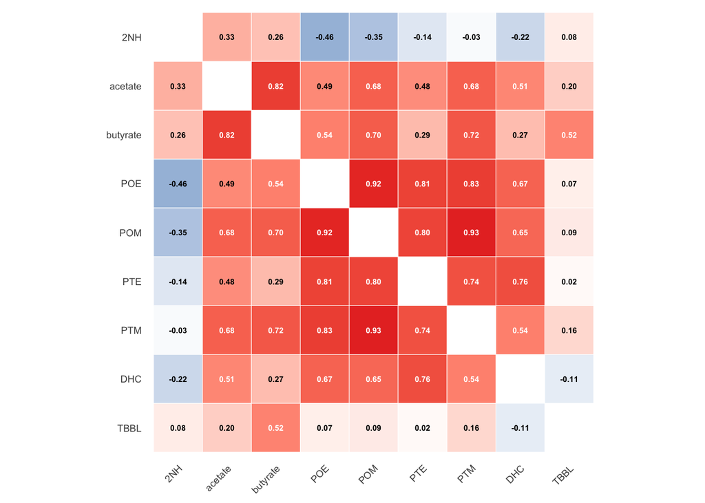

```r
corr_data <- test_ees %>%
  # Select only the columns needed for pivoting
  select(geno, sub, new_val, sig) %>%
  # Spread the data so each substrate is a column
  pivot_wider(names_from = sub, values_from = new_val) %>%
  # Remove NA genotypes
  filter(sig == TRUE) %>%
  # Remove the 'geno' column so only numeric data remains for correlation
  select(-c(geno,sig))

cor_matrix <- cor(corr_data, method = "pearson", use = "pairwise.complete.obs")

cor_tibble <- cor_matrix %>%
  as.data.frame() %>%
  rownames_to_column(var = "sub1") %>%
  as_tibble() %>%
  pivot_longer(
    cols = -sub1,
    names_to = "sub2",
    values_to = "pearsons"
  ) %>%
  # Filter out self-corrlelation
  #filter(sub1 != sub2) %>%
  mutate(across(c(sub1, sub2), ~ ifelse(. == "tbbl", "TBBL", .))) %>%
  mutate(
    sub1 = factor(sub1, levels = rev(sub_order)), # Reversed for Y-axis (Top to Bottom)
    sub2 = factor(sub2, levels = sub_order)       # Standard for X-axis (Left to Right)
  ) %>%
  filter(sub1 != sub2) # Remove perfect fits

tile <- cor_tibble %>%
  ggplot(aes(x = sub2, y = sub1, fill = pearsons)) +
  geom_tile(color = "white") +
  geom_text(aes(label = sprintf("%.2f", pearsons)),
            size = 2,
            color = ifelse(abs(cor_tibble$pearsons) > 0.5, "white", "black"),
            fontface = "bold") +
  scale_fill_gradient2(
    low = "#1F78B4", mid = "white", high = "#E31A1C",
    midpoint = 0, limit = c(-1, 1)) +
  theme_minimal() +
  theme(
    axis.text.x = element_text(angle = 45, vjust = 1, hjust = 1),
    axis.text = element_text(size = 7),
    axis.title = element_blank(),
    panel.grid = element_blank(),
    legend.position = "none"
  ) +
  coord_fixed()

tile
```

```r
ggsave("fig_4_e.svg", plot = tile, width = 180/2.2, height = 247/2.2, dpi = 600, units = "mm")
```

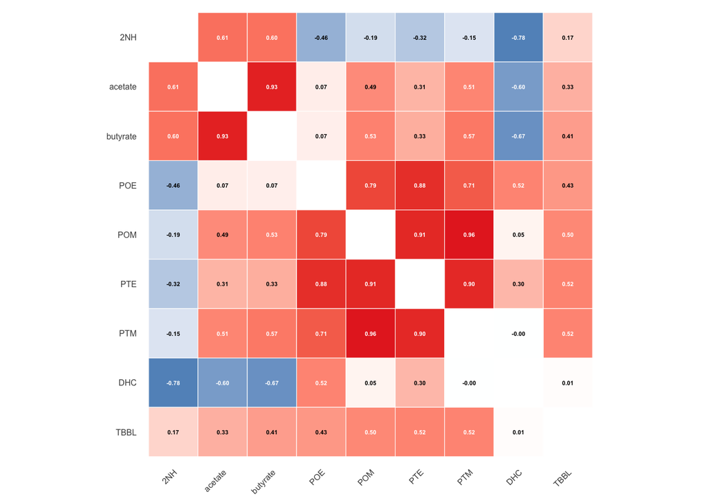

```r
# 1. Update the labels and the ordering vector first
sub_order <- c("2NH", "acetate", "butyrate", "POE", "POM", "PTE", "PTM", "DHC", "TBBL")

cor_plot_data <- bind_rows(sub_stats, (sub_stats %>% rename(sub1 = sub2, sub2 = sub1))) %>%
  # Update names to match the new order vector
  mutate(across(c(sub1, sub2), ~ ifelse(. == "tbbl", "TBBL", .))) %>%
  distinct() %>%
  filter(sub1 %in% sub_order & sub2 %in% sub_order) %>%
  mutate(
    sub1 = factor(sub1, levels = rev(sub_order)), # Reversed for Y-axis (Top to Bottom)
    sub2 = factor(sub2, levels = sub_order)       # Standard for X-axis (Left to Right)
  )

# 2. Plot
tile <- ggplot(cor_plot_data, aes(x = sub2, y = sub1, fill = pearsons)) +
  geom_tile(color = "white") +
  geom_text(aes(label = sprintf("%.2f", pearsons)),
            size = 1.5,
            color = ifelse(abs(cor_plot_data$pearsons) > 0.5, "white", "black"),
            fontface = "bold") +
  scale_fill_gradient2(
    low = "#1F78B4", mid = "white", high = "#E31A1C",
    midpoint = 0, limit = c(-1, 1)) +
  theme_minimal() +
  theme(
    axis.text.x = element_text(angle = 45, vjust = 1, hjust = 1),
    axis.text = element_text(size = 6),
    axis.title = element_blank(),
    panel.grid = element_blank(),
    legend.position = "none"
  ) +
  coord_fixed()

tile
```

```r
#ggsave("fig_2_b.svg", plot = tile, width = 180/3, height = 247/3, dpi = 600, units = "mm")
```

### 3.6.3 Heat map

For activity of all substrates

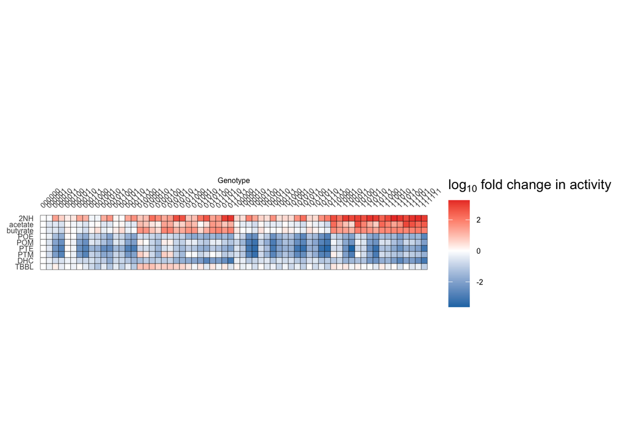

```r
tile <- normalized_bulky_mean_data %>%
  unite("geno", p233:p313, sep = "") %>%
  mutate(
    substrate = case_when(substrate == "tbbl" ~ "TBBL",
                          TRUE ~ substrate),
    geno = fct_inorder(geno),
    substrate = factor(substrate, levels = rev(c("2NH",
                                             "acetate",
                                             "butyrate",
                                             "POE",
                                             "POM",
                                             "PTE",
                                             "PTM",
                                             "DHC",
                                             "TBBL")))
  ) %>%
  ggplot(aes(x = geno, y = substrate, fill = mean_value)) +
  geom_tile(color = "black", linewidth = 0.1) +
  scale_x_discrete(position = "top") +
  scale_fill_gradient2(
    low = "#1F78B4",
    mid = "white",
    high = "#E31A1C",
    midpoint = 0
  ) +
  theme_minimal() +
  theme(
    # 45 degree tilt, adjusted for top position
    axis.text.x.top = element_text(angle = 45, hjust = 0, vjust = 0, size = 6),
    axis.title.y = element_blank(),
    axis.text.y = element_text(size = 6),
    axis.title.x.top = element_text(size = 6),
    panel.grid = element_blank(),
    legend.position = "right",
    legend.text = element_text(size = 6)
  ) +
  labs(x = "Genotype",
       fill = expression("log"[10]*" fold change in activity")) +
  coord_fixed()

tile
```

```r
# Clean figure
ggsave("fig_sub_heatmap.svg", plot = tile + theme(legend.position = "none"), width = 180, height = 247/3, dpi = 600, units = "mm")
# With legend for reference
ggsave("fig_sub_heatmap_legend.svg", plot = tile, width = 180, height = 247/3, dpi = 600, units = "mm")
```

# 4 Dimentionality reduction

## 4.1 PCA

### 4.1.1 Newer PCA

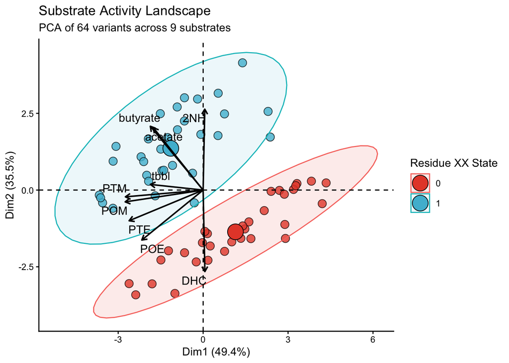

```r
# 1. Reshape the data: 1 row per genotype, 1 column per substrate
pca_wide <- normalized_bulky_mean_data %>%
  select(reference, p233, p254, p271, p272, p306, p313, substrate, mean_value) %>%
  pivot_wider(names_from = substrate, values_from = mean_value)

# 2. Isolate activity columns for the calculation
# This ensures binary mutation data doesn't skew the variance
substrates <- unique(normalized_bulky_mean_data$substrate)
pca_matrix <- pca_wide %>%
  column_to_rownames("reference") %>%
  select(all_of(substrates))

# 3. Run PCA with scaling
# Scaling is crucial because substrate activity ranges often differ
pca_res <- prcomp(pca_matrix, scale. = TRUE)

# 4. Generate a striking Biplot
fviz_pca_biplot(pca_res,
                # Genotype points
                geom.ind = "point",
                pointshape = 21,
                pointsize = 3.5,
                fill.ind = as.factor(pca_wide$p254), # Color by a key mutation
                alpha.ind = 0.8,
                # Substrate vectors (Arrows)
                col.var = "black",
                arrowsize = 0.7,
                repel = TRUE, # Prevent label overlap
                # Aesthetics
                palette = "npg", # Nature Publishing Group color palette
                addEllipses = TRUE, # Adds 'clouds' around the groups
                legend.title = "Residue XX State") +
  theme_classic() +
  labs(title = "Substrate Activity Landscape",
       subtitle = "PCA of 64 variants across 9 substrates")
```

Then 2 positions

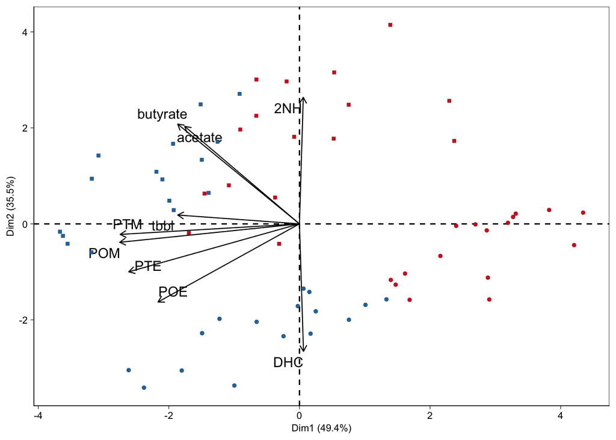

```r
# 1. Prepare the factors
pca_wide_labels <- pca_wide %>%
  mutate(p254_factor = as.factor(p254),
         p306_factor = as.factor(p306))

# 2. Build the plot
# We set habillage to NULL and add the points manually to control fill vs color
pca_plot <- fviz_pca_biplot(pca_res,
                geom.ind = "none", # Don't let fviz draw the points
                col.var = "black",
                arrowsize = 0.4,
                repel = TRUE,
                mean.point = FALSE)

# 3. Manually add the points with independent fill and shape
pca_plot_final <- pca_plot +
  geom_point(data = as.data.frame(pca_res$x),
             aes(x = PC1, y = PC2,
                 shape = pca_wide_labels$p254_factor,
                 fill = pca_wide_labels$p306_factor),
             size = 1.5, color = "black", stroke = 0.1) + # 'color' is the outline, 'fill' is the inside
  scale_fill_manual(values = c("0" = "#1F78B4", "1" = "#E31A1C")) +
  scale_shape_manual(values = c("0" = 21, "1" = 22)) +
  #guides(fill = guide_legend(override.aes = list(shape = 21))) +
  theme_classic() +
  labs(title = NULL) +
  theme(
    legend.position = "none",
    panel.border = element_rect(fill = NA, color = "black", linewidth = 0.3),
    axis.line = element_line(colour = "black", linewidth = 0.25),
    axis.ticks = element_line(linewidth = 0.2),
    axis.title = element_text(size = 8),
    axis.text = element_text(size = 8)
  )

pca_plot_final
```

```r
ggsave("fig_2_pca.svg", plot = pca_plot_final, width = 180/3, height = 180/3, dpi = 600, units = "mm")
```

### 4.1.2 Performing PCA

First it is worth to add some categorical groups into things. Examples include order (i.e. number of mutations) etc.

```r
pre_pre_data <- normalized_bulky_mean_data %>%
  rowwise() %>%
  mutate(order = sum(c(p233,p254,p271,p272,p306,p313)))
# add more groups here if needed
```

This time these are definitely not scaled

```r
# Convert data to entries of length 15
pca_data <- pre_pre_data %>%
  select(c(p233,p254,p271,p272,p306,p313,substrate,mean_value,order)) %>%
  pivot_wider(names_from = substrate, values_from = mean_value) %>%
  as.data.frame()

# Old school dataframe because PCA prefers it
rownames(pca_data) <- pca_data$ref_geno

# Generate final data
pca_final_data <- subset(pca_data, select = -order)

# Perform PCA on the 15 variables
pca_result <- prcomp(pca_final_data, scale. = F)

summary(pca_result)
```

```
## Importance of components:
##                           PC1    PC2     PC3     PC4     PC5    PC6     PC7
## Standard deviation     1.9401 1.6808 0.70623 0.62167 0.51535 0.5078 0.36360
## Proportion of Variance 0.4481 0.3363 0.05938 0.04601 0.03162 0.0307 0.01574
## Cumulative Proportion  0.4481 0.7844 0.84379 0.88980 0.92141 0.9521 0.96785
##                            PC8     PC9    PC10    PC11    PC12   PC13    PC14
## Standard deviation     0.30410 0.23711 0.22179 0.17364 0.13697 0.1085 0.08544
## Proportion of Variance 0.01101 0.00669 0.00586 0.00359 0.00223 0.0014 0.00087
## Cumulative Proportion  0.97886 0.98556 0.99141 0.99500 0.99724 0.9986 0.99951
##                           PC15
## Standard deviation     0.06435
## Proportion of Variance 0.00049
## Cumulative Proportion  1.00000
```

### 4.1.3 Visualiazing the PCA

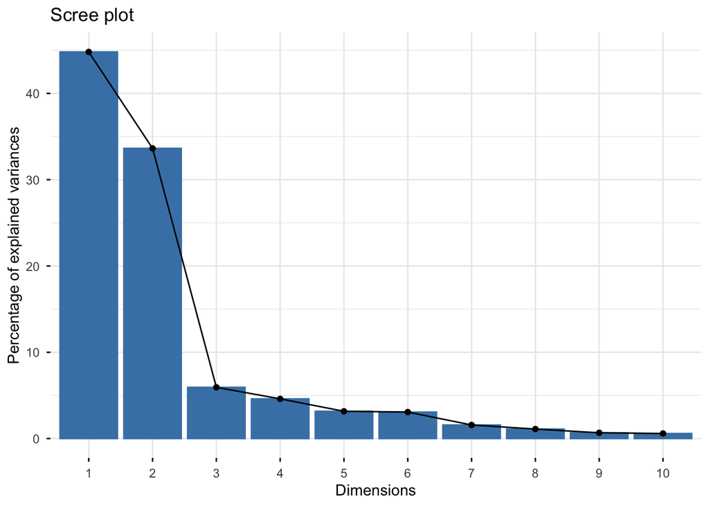

```r
fviz_eig(pca_result)
```

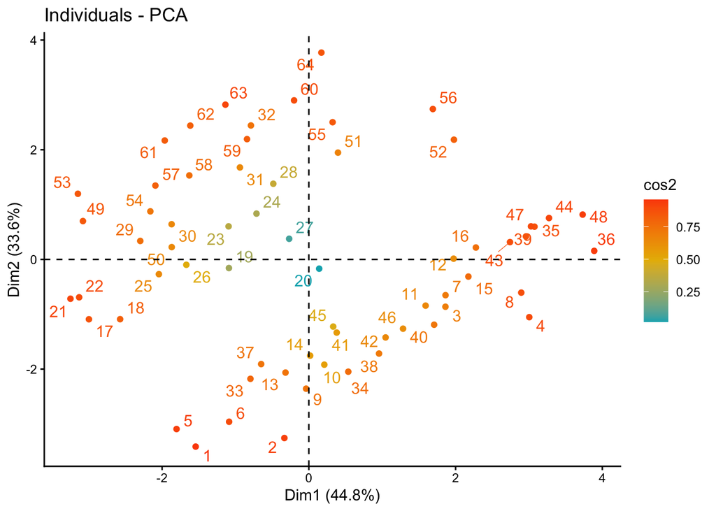

```r
# Biplot
pca_result %>%
  fviz_pca_ind(col.ind = "cos2", # Color by the quality of representation
               gradient.cols = c("#00AFBB", "#E7B800", "#FC4E07"),
               repel = TRUE # Avoid text overlapping
             ) +
  theme_classic()
```

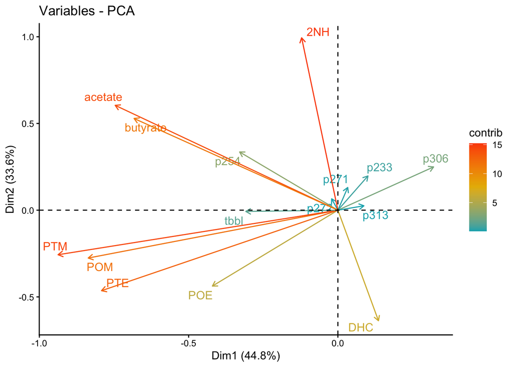

```r
pca_result %>%
  fviz_pca_var(col.var = "contrib", # Color by contributions to the PC
               gradient.cols = c("#00AFBB", "#E7B800", "#FC4E07"),
               repel = TRUE # Avoid text overlapping
             ) +
  theme_classic()
```

Interpreting these results is difficult because as it turns out, traditional PCA analysis on these data is incorrect, as the encoding for mutations (0 and 1) is put on the same scale as activity. These are not true continuous data and thus should not be represented on this scale.

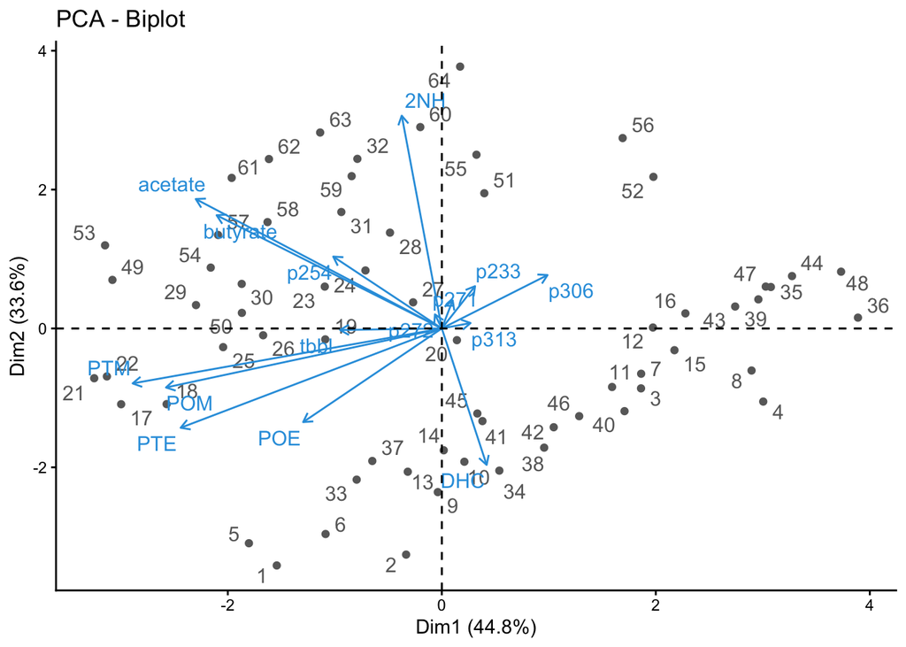

```r
pca_result %>%
  fviz_pca_biplot(repel = TRUE,
                  col.var = "#2E9FDF", # Variables color
                  col.ind = "#696969"  # Individuals color
             ) +
  theme_classic()
```

Combining the two analyses is obviously noisy.

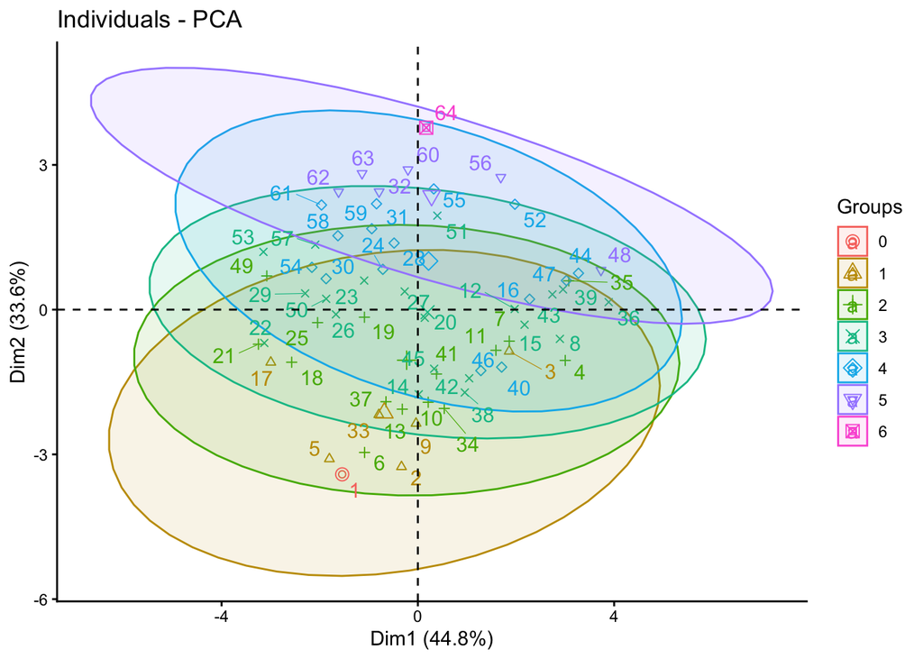

```r
mutational_order <- as.factor(pca_data$order)
pca_result %>%
  fviz_pca_ind(col.ind = mutational_order, # color by order
               addEllipses = TRUE, # Concentration ellipses
               legend.title = "Groups",
               repel = TRUE
             ) +
  theme_classic()
```

Here groups represent the mutational order. These results are hard to interpret when not normalized.